# Safer Washington

Cade Jeong, Elizabeth McCrady, Busung Chung, Sanika Gadam

AU 2022

### Introduction

For our project, we have found and used four different datasets and this rmd file is all about summarizing the datasets to a easily understandable, readable format along with visualizations.

The Datasets:

- **cjdb** from [SAC](https://sac.ofm.wa.gov/data) which has 1271 observations and 228 variables containing every possible information about crimes in Washington State from 1990-2020.
- **srs** from [SAC](https://sac.ofm.wa.gov/data) which has 5283 observations and 22 variables containing information about crimes in Washington State that are reported using the SummaryReportingSystem from 1994 - 2018.
- **nibrs** from [SAC](https://sac.ofm.wa.gov/data) which has 2357 observations and 34 variables containing information about crimes in Washington State that are reported using the NationalIncidentBasedReportingSystem from 2012~.
- **spd** from [SeattleOpenData](https://data.seattle.gov/Public-Safety/SPD-Crime-Data-2008-Present/tazs-3rd5) which originally has 1,011,283 observations and 17 variables containing information about crimes in Seattle reported by the SPD from 2008 - present. This data set gets updated daily.

### Summary

Working with the cjdb data set, we have found some interesting information about the number of crimes and arrests in certain years (sum of all counties) and counties (sum of all years), and the most and the least common types of crimes in Washington State (sum of all years and counties). Here is the summary of those information:

The year with the most number of crimes in Washington State is 2020, with 499418 crimes total. The year with the least number of crimes in Washington State is 2011, with 258996 crimes total. The county with the most number of crimes in Washington State is KING county, with 3708979 crimes total. The county with the least number of crimes in Washington State is WAHKIAKUM county, with 2621 crimes total. The year with the most number of arrests in Washington State is 2007, with 265050 arrests total. The year with the least number of arrests in Washington State is 2020, with 147016 arrests total. The county with the most number of arrests in Washington State is KING county, with 1601179 arrests total. The county with the least number of arrests in Washington State is WAHKIAKUM county, with 627 arrests total. The most common type of crime that took place in Washington State is THEFT which is mostly a motor vehicle theft. The least common type of crime that took place in Washington State is GAMBVIOL, which is a shortened name for gamble violence.

### Table

|  | county | CRIME_TOTALS | ARREST_TOTALS | ARREST_RATIO |
| --- | --- | --- | --- | --- |
| 1 | ADAMS | 32197 | 26235 | 0.814827468397677 |
| 2 | ASOTIN | 30113 | 35077 | 1.16484574768372 |
| 3 | BENTON | 231625 | 265115 | 1.1445871559633 |
| 4 | CHELAN | 98415 | 93492 | 0.949977137631459 |
| 5 | CLALLAM | 90748 | 69027 | 0.760644862696699 |
| 6 | CLARK | 476479 | 299062 | 0.627649906921396 |
| 7 | COLUMBIA | 6050 | 2104 | 0.347768595041322 |
| 8 | COWLITZ | 178571 | 143017 | 0.800897122153093 |
| 9 | DOUGLAS | 39895 | 30868 | 0.773731043990475 |
| 10 | FERRY | 3398 | 3304 | 0.972336668628605 |

[output cut: 29 more lines]

We have made a table that contains a cumulative sum of number of crimes that occurred in Washington State by counties along with cumulative sum of number of arrests. And also with the arrest ratio to see how much of the criminals gets arrested. The numbers that are seen here make sense for some counties but does not make sense for some. The counties that have more arrests than crimes (ARREST_RATIO > 1) are ones that possibly have caught the criminals year(s) after their crime, or caught criminals who escaped from different counties, or maybe arrest people for fun… And the counties that have really low ARREST_RATIO probably means that the crimes were less severe or have a very bad safety to live there.

### Charts

#### Chart 1: Did the crime get worse or better during the years we suffered from COVID-19? (line; Liz)

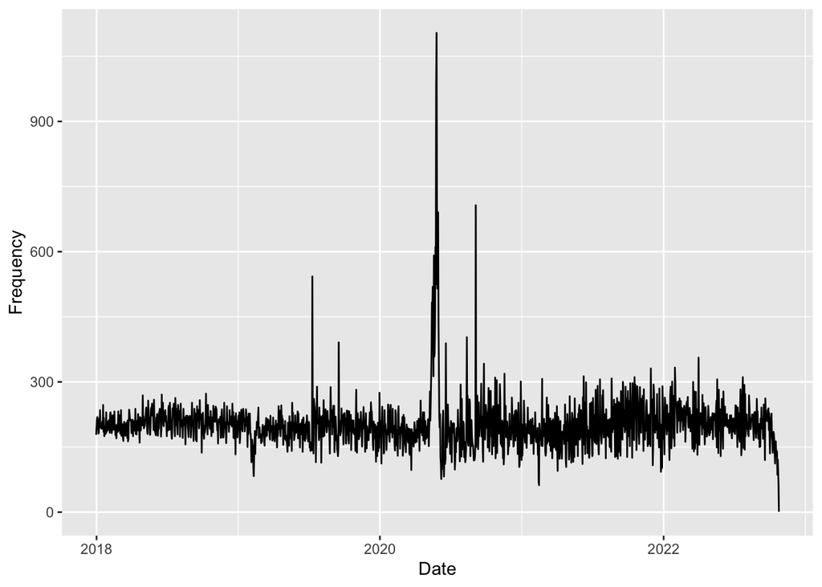

I was using our SPD data from our project proposal. Due to making the data fit again on our repository I had to shorten the csv file but I promise I was working with the whole thing at the time of data wrangling. So now, looking at this data we can see crime ranging from the beginning of 2018 to November 2022. The data is a little messy but we can see peaks and and declines of the frequency of crime per date. COVID-19 began in late 2019 and since its beginning we see a large peak in the middle of 2020. We also know that during this time was the beginning of the Black Lives Matter movement which might attribute to this peak of crime since there were a lot more people going outside instead of staying inside during quarantine. THe whole chart seems pretty consistent with the frequency of crime and we only see a drop more recent in later 2022.

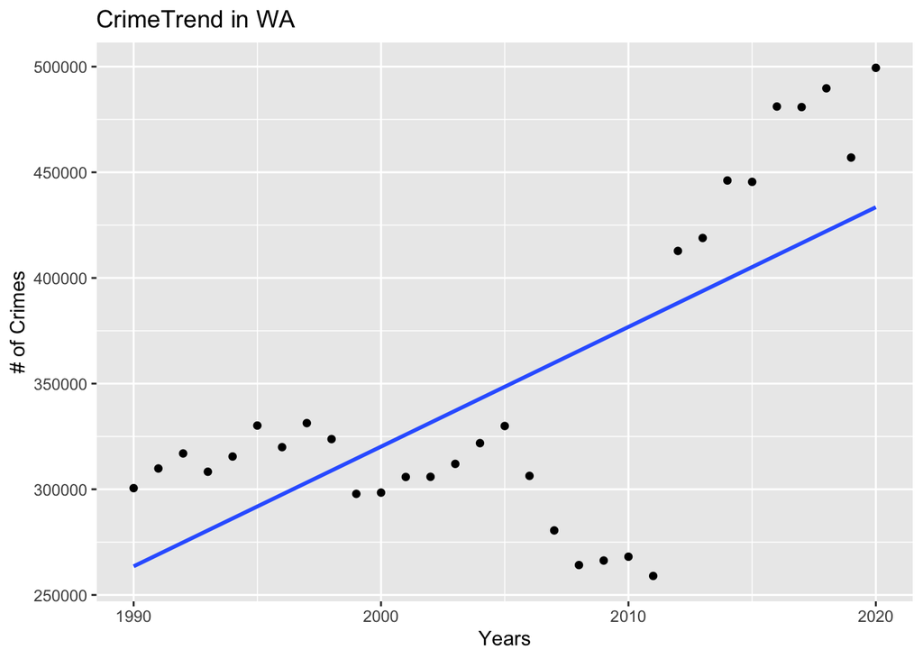

#### Chart 3: What kind of or type of crime is most common in Washington State? (bar; Busung)

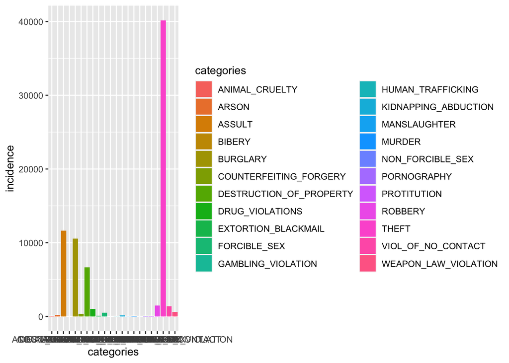

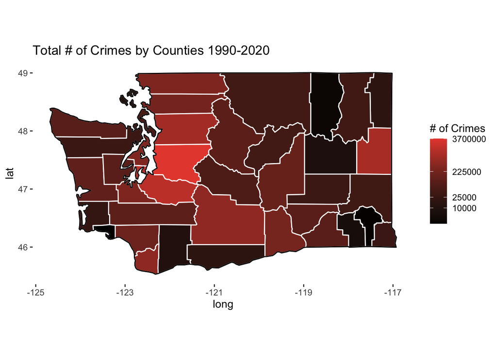

This chart is an extra that is added for my (Cade) practice. I included this chart because I wanted to try making a chart that uses maps and in this case, a Washington State map with county borders shown. The information that is available from this chart is the total number of crimes in each of the counties in Washington State from 1990-2020 using cjdb data set. The brighter red it gets, the more crime has occurred in that county. This would have looked much better if I could insert the names and actual numbers, but was out of my abilities and this was the best I could make. One thing, I can confidently inform you is that King county had the *most* crimes through out the years.